# Data Analysis of the “War of the Five Kings” - Game of Thrones

## Introduction

The War of the Five Kings is a famous civil war described in the well-known serious fantasy novel “Game of Thrones”. This is a civil strife with an unprecedented scale that involves seven kingdoms. As the name implies, a total of five persons claim to be the king during the war: Joffrey Baratheon, Stannis Baratheon and Renly Baratheon all claim to be the rightful heir of the iron throne. Moreover, Robb Stark is elected by the barons of the northern border to the King in the North, and Balon Greyjoy erects the flag of independence again and claims to be the King of the Iron Islands, in an attempt to shake off the ruling of the Iron Throne.

This dataset (battles.csv) contains all the battles during the War of the Five Kings. It is part of the [Game of Thrones](https://www.kaggle.com/mylesoneill/game-of-thrones) in Kaggle.

Variables in the dataset and meanings:

- **name:** String variable. The name of the battle.
- **year:** Numeric variable. The year of the battle.
- **battle_number:** Numeric variable. A unique ID number for the battle.
- **attacker_king:** Categorical. The attacker's king. A slash indicators that the king charges over the course of the war. For example, "Joffrey/Tommen Baratheon" is coded as such because one king follows the other in the Iron Throne.
- **defender_king:** Categorical variable. The defender's king.
- **attacker_1:** String variable. Major house attacking.
- **attacker_2:** String variable. Major house attacking.
- **attacker_3:** String variable. Major house attacking.
- **attacker_4:** String variable. Major house attacking.
- **defender_1:** String variable. Major house defending.
- **defender_2:** String variable. Major house defending.
- **defender_3:** String variable. Major house defending.
- **defender_4:** String variable. Major house defending.
- **attacker_outcome:** Categorical variable. The outcome from the perspective of the attacker. Categories: win, loss, draw.
- **battle_type:** Categorical variable. A classification of the battle's primary type. Categories:
  - pitched_battle: Armies meet in a location and fight. This is also the baseline category.
  - ambush: A battle where stealth or subterfuge was the primary means of attack.
  - siege: A prolonged of a fortied position.
  - razing: An attack against an undefended position
- **major_death:** Binary variable. If there was a death of a major figure during the battle.
- **major_capture:** Binary variable. If there was the capture of the major figure during the battle.
- **attacker_size:** Numeric variable. The size of the attacker's force. No distinction is made between the types of soldiers such as cavalry and footmen.
- **defender_size:** Numeric variable. The size of the defenders's force. No distinction is made between the types of soldiers such as cavalry and footmen.
- **attacker_commander:** String variable. Major commanders of the attackers. Commander's names are included without honoric titles and commandders are seperated by commas.
- **defender_commander:** String variable. Major commanders of the defener. Commander's names are included without honoric titles and commandders are seperated by commas.
- **summer:** Binary variable. Was it summer?
- **location:** String variable. The location of the battle.
- **region:** Categorical variable. The region where the battle takes place. Categories: Beyond the Wall, The North, The Iron Islands, The Riverlands, The Vale of Arryn, The Westerlands, The Crownlands, The Reach, The Stormlands, Dorne
- **note:** String variable. Coding notes regarding individual observations..

## Project Instructions

We have provided the data analysis flow for this project, but you will have to complete the codes by yourself. Your failure to complete this project means you are temporarily incapable to achieve the nanodegree of data analysis (advanced). We suggest you achieve a nanodegree of data analysis (introductory) and master the knowledge required to proceed with the advanced course.

Records in the process of data analysis are also an important part of the data analysis report. You can insert markdown cells where you need to record your key steps and reasoning processes during the data analysis. For example, what characteristics do data have? What do statistical data mean? What conclusion can you derive from visualization? What’s your analysis next step? Why do you perform the analysis? If you fail to do this, you can’t pass this project.

> **Tip**: Quoted sections like this will provide helpful instructions on how to navigate and use an iPython notebook.

## Ask questions

Under this project, you will perform an explorative analysis of data as a data analyst. You will understand the basic flow of data analysis. Before starting data analysis, please think several questions about these battles you will have to understand. For example, what region sees the largest number of battles? What king wins the most victories? What key factors influence the outcome of a battle?

**Question**：Please write down questions you’re interested in and ensure all these questions can be answered with data available now. (To ensure the learning effect, please ensure your data analysis report can contain two visualization analysis chapters and one correlation analysis chapter.）

**Answer**：what region sees the largest number of battles? What king wins the most victories? What key factors influence the outcome of a battle?

After setting questions, we will start importing data and perform an explorative analysis to answer the questions set above.

> **Tip**: If you double click on this cell, you will see the text change so that all of the formatting is removed. This allows you to edit this block of text. This block of text is written using [Markdown](http://daringfireball.net/projects/markdown/syntax), which is a way to format text using headers, links, italics, and many other options. You will learn more about Markdown later in the Nanodegree Program. Hit **Shift** + **Enter** or **Shift** + **Return**.

## Data Wrangling

> **Tip**: You can run a code cell like you formatted Markdown cells by clicking on the cell and using the keyboard shortcut **Shift** + **Enter** or **Shift** + **Return**. Alternatively, a code cell can be executed using the **Play** button in the toolbar after selecting it. While the cell is running, you will see an asterisk in the message to the left of the cell, i.e. `In [*]:`. The asterisk will change into a number to show that execution has completed, e.g. `In [1]`. If there is output, it will show up as `Out [1]:`, with an appropriate number to match the "In" number.

```python
# TO DO: load pacakges
import pandas as pd
import numpy as np
from collections import Counter
import statsmodels.api as sm
import matplotlib.pyplot as plt
```

```python
# TO DO: load the dataset
df = pd.read_csv("battles.csv")
```

```python
# TO DO: check the dataset general info
df.info()
```

```
<class 'pandas.core.frame.DataFrame'>
RangeIndex: 38 entries, 0 to 37
Data columns (total 25 columns):
name                  38 non-null object
year                  38 non-null int64
battle_number         38 non-null int64
attacker_king         36 non-null object
defender_king         35 non-null object
attacker_1            38 non-null object
attacker_2            10 non-null object
attacker_3            3 non-null object
attacker_4            2 non-null object
defender_1            37 non-null object
defender_2            2 non-null object
defender_3            0 non-null float64
defender_4            0 non-null float64
attacker_outcome      37 non-null object
battle_type           37 non-null object
major_death           37 non-null float64
major_capture         37 non-null float64
attacker_size         24 non-null float64
defender_size         19 non-null float64
attacker_commander    37 non-null object
defender_commander    28 non-null object
summer                37 non-null float64
location              37 non-null object
region                38 non-null object
note                  5 non-null object
dtypes: float64(7), int64(2), object(16)
memory usage: 7.5+ KB
```

```python
# TO DO: clean the data (optional: only there are problems)
# user mean value replace nan
major_death = df["major_death"].mean()
df["major_death"].fillna(major_death, inplace = True)
```

```python
# user mean value replace nan
major_capture = df["major_capture"].mean()
df["major_capture"].fillna(major_capture, inplace = True)
df.info()
```

```
<class 'pandas.core.frame.DataFrame'>
RangeIndex: 38 entries, 0 to 37
Data columns (total 25 columns):
name                  38 non-null object
year                  38 non-null int64
battle_number         38 non-null int64
attacker_king         36 non-null object
defender_king         35 non-null object
attacker_1            38 non-null object
attacker_2            10 non-null object
attacker_3            3 non-null object
attacker_4            2 non-null object
defender_1            37 non-null object
defender_2            2 non-null object
defender_3            0 non-null float64
defender_4            0 non-null float64
attacker_outcome      37 non-null object
battle_type           37 non-null object
major_death           38 non-null float64
major_capture         38 non-null float64
attacker_size         24 non-null float64
defender_size         19 non-null float64
attacker_commander    37 non-null object
defender_commander    28 non-null object
summer                37 non-null float64
location              37 non-null object
region                38 non-null object
note                  5 non-null object
dtypes: float64(7), int64(2), object(16)
memory usage: 7.5+ KB
```

```python
# user mean value replace nan
attacker_size = df["attacker_size"].mean()
df["attacker_size"].fillna(attacker_size, inplace = True)
df.info()
```

```
<class 'pandas.core.frame.DataFrame'>
RangeIndex: 38 entries, 0 to 37
Data columns (total 25 columns):
name                  38 non-null object
year                  38 non-null int64
battle_number         38 non-null int64
attacker_king         36 non-null object
defender_king         35 non-null object
attacker_1            38 non-null object
attacker_2            10 non-null object
attacker_3            3 non-null object
attacker_4            2 non-null object
defender_1            37 non-null object
defender_2            2 non-null object
defender_3            0 non-null float64
defender_4            0 non-null float64
attacker_outcome      37 non-null object
battle_type           37 non-null object
major_death           38 non-null float64
major_capture         38 non-null float64
attacker_size         38 non-null float64
defender_size         19 non-null float64
attacker_commander    37 non-null object
defender_commander    28 non-null object
summer                37 non-null float64
location              37 non-null object
region                38 non-null object
note                  5 non-null object
dtypes: float64(7), int64(2), object(16)
memory usage: 7.5+ KB
```

```python
# user mean value replace nan
defender_size = df["defender_size"].mean()
df["defender_size"].fillna(defender_size, inplace = True)
df.info()
```

```
<class 'pandas.core.frame.DataFrame'>
RangeIndex: 38 entries, 0 to 37
Data columns (total 25 columns):
name                  38 non-null object
year                  38 non-null int64
battle_number         38 non-null int64
attacker_king         36 non-null object
defender_king         35 non-null object
attacker_1            38 non-null object
attacker_2            10 non-null object
attacker_3            3 non-null object
attacker_4            2 non-null object
defender_1            37 non-null object
defender_2            2 non-null object
defender_3            0 non-null float64
defender_4            0 non-null float64
attacker_outcome      37 non-null object
battle_type           37 non-null object
major_death           38 non-null float64
major_capture         38 non-null float64
attacker_size         38 non-null float64
defender_size         38 non-null float64
attacker_commander    37 non-null object
defender_commander    28 non-null object
summer                37 non-null float64
location              37 non-null object
region                38 non-null object
note                  5 non-null object
dtypes: float64(7), int64(2), object(16)
memory usage: 7.5+ KB
```

```python
df.drop(['defender_3','defender_4'],axis=1)
```

|  | name | year | battle_number | attacker_king | defender_king | attacker_1 | attacker_2 | attacker_3 | attacker_4 | defender_1 | ... | major_death | major_capture | attacker_size | defender_size | attacker_commander | defender_commander | summer | location | region | note |
| --- | --- | --- | --- | --- | --- | --- | --- | --- | --- | --- | --- | --- | --- | --- | --- | --- | --- | --- | --- | --- | --- |
| 0 | Battle of the Golden Tooth | 298 | 1 | Joffrey/Tommen Baratheon | Robb Stark | Lannister | NaN | NaN | NaN | Tully | ... | 1.000000 | 0.000000 | 15000.000000 | 4000.000000 | Jaime Lannister | Clement Piper, Vance | 1.0 | Golden Tooth | The Westerlands | NaN |
| 1 | Battle at the Mummer's Ford | 298 | 2 | Joffrey/Tommen Baratheon | Robb Stark | Lannister | NaN | NaN | NaN | Baratheon | ... | 1.000000 | 0.000000 | 9942.541667 | 120.000000 | Gregor Clegane | Beric Dondarrion | 1.0 | Mummer's Ford | The Riverlands | NaN |
| 2 | Battle of Riverrun | 298 | 3 | Joffrey/Tommen Baratheon | Robb Stark | Lannister | NaN | NaN | NaN | Tully | ... | 0.000000 | 1.000000 | 15000.000000 | 10000.000000 | Jaime Lannister, Andros Brax | Edmure Tully, Tytos Blackwood | 1.0 | Riverrun | The Riverlands | NaN |
| 3 | Battle of the Green Fork | 298 | 4 | Robb Stark | Joffrey/Tommen Baratheon | Stark | NaN | NaN | NaN | Lannister | ... | 1.000000 | 1.000000 | 18000.000000 | 20000.000000 | Roose Bolton, Wylis Manderly, Medger Cerwyn, H... | Tywin Lannister, Gregor Clegane, Kevan Lannist... | 1.0 | Green Fork | The Riverlands | NaN |
| 4 | Battle of the Whispering Wood | 298 | 5 | Robb Stark | Joffrey/Tommen Baratheon | Stark | Tully | NaN | NaN | Lannister | ... | 1.000000 | 1.000000 | 1875.000000 | 6000.000000 | Robb Stark, Brynden Tully | Jaime Lannister | 1.0 | Whispering Wood | The Riverlands | NaN |
| 5 | Battle of the Camps | 298 | 6 | Robb Stark | Joffrey/Tommen Baratheon | Stark | Tully | NaN | NaN | Lannister | ... | 0.000000 | 0.000000 | 6000.000000 | 12625.000000 | Robb Stark, Tytos Blackwood, Brynden Tully | Lord Andros Brax, Forley Prester | 1.0 | Riverrun | The Riverlands | NaN |
| 6 | Sack of Darry | 298 | 7 | Joffrey/Tommen Baratheon | Robb Stark | Lannister | NaN | NaN | NaN | Darry | ... | 0.000000 | 0.000000 | 9942.541667 | 6428.157895 | Gregor Clegane | Lyman Darry | 1.0 | Darry | The Riverlands | NaN |
| 7 | Battle of Moat Cailin | 299 | 8 | Balon/Euron Greyjoy | Robb Stark | Greyjoy | NaN | NaN | NaN | Stark | ... | 0.000000 | 0.000000 | 9942.541667 | 6428.157895 | Victarion Greyjoy | NaN | 1.0 | Moat Cailin | The North | NaN |
| 8 | Battle of Deepwood Motte | 299 | 9 | Balon/Euron Greyjoy | Robb Stark | Greyjoy | NaN | NaN | NaN | Stark | ... | 0.000000 | 0.000000 | 1000.000000 | 6428.157895 | Asha Greyjoy | NaN | 1.0 | Deepwood Motte | The North | NaN |
| 9 | Battle of the Stony Shore | 299 | 10 | Balon/Euron Greyjoy | Robb Stark | Greyjoy | NaN | NaN | NaN | Stark | ... | 0.000000 | 0.000000 | 264.000000 | 6428.157895 | Theon Greyjoy | NaN | 1.0 | Stony Shore | The North | Greyjoy's troop number based on the Battle of ... |
| 10 | Battle of Torrhen's Square | 299 | 11 | Robb Stark | Balon/Euron Greyjoy | Stark | NaN | NaN | NaN | Greyjoy | ... | 0.000000 | 0.000000 | 244.000000 | 900.000000 | Rodrik Cassel, Cley Cerwyn | Dagmer Cleftjaw | 1.0 | Torrhen's Square | The North | Greyjoy's troop number comes from the 264 esti... |
| 11 | Battle of Winterfell | 299 | 12 | Balon/Euron Greyjoy | Robb Stark | Greyjoy | NaN | NaN | NaN | Stark | ... | 0.000000 | 1.000000 | 20.000000 | 6428.157895 | Theon Greyjoy | Bran Stark | 1.0 | Winterfell | The North | It isn't mentioned how many Stark men are left... |
| 12 | Sack of Torrhen's Square | 299 | 13 | Balon/Euron Greyjoy | Balon/Euron Greyjoy | Greyjoy | NaN | NaN | NaN | Stark | ... | 0.000000 | 1.000000 | 9942.541667 | 6428.157895 | Dagmer Cleftjaw | NaN | 1.0 | Torrhen's Square | The North | NaN |
| 13 | Sack of Winterfell | 299 | 14 | Joffrey/Tommen Baratheon | Robb Stark | Bolton | Greyjoy | NaN | NaN | Stark | ... | 1.000000 | 0.000000 | 618.000000 | 2000.000000 | Ramsay Snow, Theon Greyjoy | Rodrik Cassel, Cley Cerwyn, Leobald Tallhart | 1.0 | Winterfell | The North | Since House Bolton betrays the Starks for Hous... |
| 14 | Battle of Oxcross | 299 | 15 | Robb Stark | Joffrey/Tommen Baratheon | Stark | Tully | NaN | NaN | Lannister | ... | 1.000000 | 1.000000 | 6000.000000 | 10000.000000 | Robb Stark, Brynden Tully | Stafford Lannister, Roland Crakehall, Antario ... | 1.0 | Oxcross | The Westerlands | NaN |
| 15 | Siege of Storm's End | 299 | 16 | Stannis Baratheon | Renly Baratheon | Baratheon | NaN | NaN | NaN | Baratheon | ... | 1.000000 | 0.000000 | 5000.000000 | 20000.000000 | Stannis Baratheon, Davos Seaworth | Renly Baratheon, Cortnay Penrose, Loras Tyrell... | 1.0 | Storm's End | The Stormlands | NaN |
| 16 | Battle of the Fords | 299 | 17 | Joffrey/Tommen Baratheon | Robb Stark | Lannister | NaN | NaN | NaN | Tully | ... | 0.000000 | 0.000000 | 20000.000000 | 10000.000000 | Tywin Lannister, Flement Brax, Gregor Clegane,... | Edmure Tully, Jason Mallister, Karyl Vance | 1.0 | Red Fork | The Riverlands | NaN |
| 17 | Sack of Harrenhal | 299 | 18 | Robb Stark | Joffrey/Tommen Baratheon | Stark | NaN | NaN | NaN | Lannister | ... | 1.000000 | 0.000000 | 100.000000 | 100.000000 | Roose Bolton, Vargo Hoat, Robett Glover | Amory Lorch | 1.0 | Harrenhal | The Riverlands | NaN |
| 18 | Battle of the Crag | 299 | 19 | Robb Stark | Joffrey/Tommen Baratheon | Stark | NaN | NaN | NaN | Lannister | ... | 0.000000 | 0.000000 | 6000.000000 | 6428.157895 | Robb Stark, Smalljon Umber, Black Walder Frey | Rolph Spicer | 1.0 | Crag | The Westerlands | NaN |
| 19 | Battle of the Blackwater | 299 | 20 | Stannis Baratheon | Joffrey/Tommen Baratheon | Baratheon | NaN | NaN | NaN | Lannister | ... | 1.000000 | 1.000000 | 21000.000000 | 7250.000000 | Stannis Baratheon, Imry Florent, Guyard Morrig... | Tyrion Lannister, Jacelyn Bywater, Sandor Cleg... | 1.0 | King's Landing | The Crownlands | NaN |
| 20 | Siege of Darry | 299 | 21 | Robb Stark | Joffrey/Tommen Baratheon | Darry | NaN | NaN | NaN | Lannister | ... | 0.000000 | 0.000000 | 9942.541667 | 6428.157895 | Helman Tallhart | NaN | 1.0 | Darry | The Riverlands | NaN |
| 21 | Battle of Duskendale | 299 | 22 | Robb Stark | Joffrey/Tommen Baratheon | Stark | NaN | NaN | NaN | Lannister | ... | 1.000000 | 0.000000 | 3000.000000 | 6428.157895 | Robertt Glover, Helman Tallhart | Randyll Tarly, Gregor Clegane | 1.0 | Duskendale | The Crownlands | NaN |
| 22 | Battle of the Burning Septry | 299 | 23 | NaN | NaN | Brotherhood without Banners | NaN | NaN | NaN | Brave Companions | ... | 0.000000 | 0.000000 | 9942.541667 | 6428.157895 | NaN | NaN | 1.0 | NaN | The Riverlands | NaN |
| 23 | Battle of the Ruby Ford | 299 | 24 | Joffrey/Tommen Baratheon | Robb Stark | Lannister | NaN | NaN | NaN | Stark | ... | 0.000000 | 0.000000 | 9942.541667 | 6000.000000 | Gregor Clegane | Roose Bolton, Wylis Manderly | NaN | Ruby Ford | The Riverlands | NaN |
| 24 | Retaking of Harrenhal | 299 | 25 | Joffrey/Tommen Baratheon | NaN | Lannister | NaN | NaN | NaN | Brave Companions | ... | 1.000000 | 0.000000 | 9942.541667 | 6428.157895 | Gregor Clegane | Vargo Hoat | 1.0 | Harrenhal | The Riverlands | NaN |
| 25 | The Red Wedding | 299 | 26 | Joffrey/Tommen Baratheon | Robb Stark | Frey | Bolton | NaN | NaN | Stark | ... | 1.000000 | 1.000000 | 3500.000000 | 3500.000000 | Walder Frey, Roose Bolton, Walder Rivers | Robb Stark | 1.0 | The Twins | The Riverlands | This observation refers to the battle against ... |
| 26 | Siege of Seagard | 299 | 27 | Robb Stark | Joffrey/Tommen Baratheon | Frey | NaN | NaN | NaN | Mallister | ... | 0.000000 | 1.000000 | 9942.541667 | 6428.157895 | Walder Frey | Jason Mallister | 1.0 | Seagard | The Riverlands | NaN |
| 27 | Battle of Castle Black | 300 | 28 | Stannis Baratheon | Mance Rayder | Free folk | Thenns | Giants | NaN | Night's Watch | ... | 1.000000 | 1.000000 | 100000.000000 | 1240.000000 | Mance Rayder, Tormund Giantsbane, Harma Dogshe... | Stannis Baratheon, Jon Snow, Donal Noye, Cotte... | 0.0 | Castle Black | Beyond the Wall | NaN |
| 28 | Fall of Moat Cailin | 300 | 29 | Joffrey/Tommen Baratheon | Balon/Euron Greyjoy | Bolton | NaN | NaN | NaN | Greyjoy | ... | 0.000000 | 0.000000 | 9942.541667 | 6428.157895 | Ramsey Bolton | NaN | 0.0 | Moat Cailin | The North | NaN |
| 29 | Sack of Saltpans | 300 | 30 | NaN | NaN | Brave Companions | NaN | NaN | NaN | NaN | ... | 0.000000 | 0.000000 | 9942.541667 | 6428.157895 | Rorge | NaN | 0.0 | Saltpans | The Riverlands | NaN |
| 30 | Retaking of Deepwood Motte | 300 | 31 | Stannis Baratheon | Balon/Euron Greyjoy | Baratheon | Karstark | Mormont | Glover | Greyjoy | ... | 0.000000 | 0.000000 | 4500.000000 | 200.000000 | Stannis Baratheon, Alysane Mormot | Asha Greyjoy | 0.0 | Deepwood Motte | The North | NaN |
| 31 | Battle of the Shield Islands | 300 | 32 | Balon/Euron Greyjoy | Joffrey/Tommen Baratheon | Greyjoy | NaN | NaN | NaN | Tyrell | ... | 0.000000 | 0.000000 | 9942.541667 | 6428.157895 | Euron Greyjoy, Victarion Greyjoy | NaN | 0.0 | Shield Islands | The Reach | NaN |
| 32 | Invasion of Ryamsport, Vinetown, and Starfish ... | 300 | 33 | Balon/Euron Greyjoy | Joffrey/Tommen Baratheon | Greyjoy | NaN | NaN | NaN | Tyrell | ... | 0.000000 | 0.000000 | 9942.541667 | 6428.157895 | Euron Greyjoy, Victarion Greyjoy | NaN | 0.0 | Ryamsport, Vinetown, Starfish Harbor | The Reach | NaN |
| 33 | Second Seige of Storm's End | 300 | 34 | Joffrey/Tommen Baratheon | Stannis Baratheon | Baratheon | NaN | NaN | NaN | Baratheon | ... | 0.000000 | 0.000000 | 9942.541667 | 200.000000 | Mace Tyrell, Mathis Rowan | Gilbert Farring | 0.0 | Storm's End | The Stormlands | NaN |
| 34 | Siege of Dragonstone | 300 | 35 | Joffrey/Tommen Baratheon | Stannis Baratheon | Baratheon | NaN | NaN | NaN | Baratheon | ... | 0.000000 | 0.000000 | 2000.000000 | 6428.157895 | Loras Tyrell, Raxter Redwyne | Rolland Storm | 0.0 | Dragonstone | The Stormlands | NaN |
| 35 | Siege of Riverrun | 300 | 36 | Joffrey/Tommen Baratheon | Robb Stark | Lannister | Frey | NaN | NaN | Tully | ... | 0.000000 | 0.000000 | 3000.000000 | 6428.157895 | Daven Lannister, Ryman Fey, Jaime Lannister | Brynden Tully | 0.0 | Riverrun | The Riverlands | NaN |
| 36 | Siege of Raventree | 300 | 37 | Joffrey/Tommen Baratheon | Robb Stark | Bracken | Lannister | NaN | NaN | Blackwood | ... | 0.000000 | 1.000000 | 1500.000000 | 6428.157895 | Jonos Bracken, Jaime Lannister | Tytos Blackwood | 0.0 | Raventree | The Riverlands | NaN |
| 37 | Siege of Winterfell | 300 | 38 | Stannis Baratheon | Joffrey/Tommen Baratheon | Baratheon | Karstark | Mormont | Glover | Bolton | ... | 0.351351 | 0.297297 | 5000.000000 | 8000.000000 | Stannis Baratheon | Roose Bolton | 0.0 | Winterfell | The North | NaN |

38 rows × 23 columns

```python
# user mean value replace nan
summer = df["summer"].mean()
df["summer"].fillna(summer, inplace = True)
df.info()
```

```
<class 'pandas.core.frame.DataFrame'>
RangeIndex: 38 entries, 0 to 37
Data columns (total 25 columns):
name                  38 non-null object
year                  38 non-null int64
battle_number         38 non-null int64
attacker_king         36 non-null object
defender_king         35 non-null object
attacker_1            38 non-null object
attacker_2            10 non-null object
attacker_3            3 non-null object
attacker_4            2 non-null object
defender_1            37 non-null object
defender_2            2 non-null object
defender_3            0 non-null float64
defender_4            0 non-null float64
attacker_outcome      37 non-null object
battle_type           37 non-null object
major_death           38 non-null float64
major_capture         38 non-null float64
attacker_size         38 non-null float64
defender_size         38 non-null float64
attacker_commander    37 non-null object
defender_commander    28 non-null object
summer                38 non-null float64
location              37 non-null object
region                38 non-null object
note                  5 non-null object
dtypes: float64(7), int64(2), object(16)
memory usage: 7.5+ KB
```

## Exploratory data analysis

```python
# the region which see the largest number of battles
regions = []
for region in df['region'].values :
  regions.append(region)
Counter(regions)
```

```
Counter({'The Westerlands': 3,
         'The Riverlands': 17,
         'The North': 10,
         'The Stormlands': 3,
         'The Crownlands': 2,
         'Beyond the Wall': 1,
         'The Reach': 2})
```

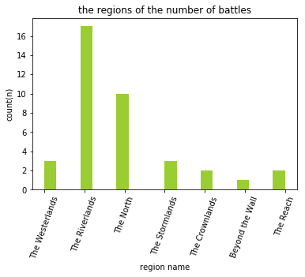

```python
# show plt
plt.hist(regions,20,color='yellowgreen')
plt.title('the regions of the number of battles')
plt.xticks(rotation=70)
plt.ylabel('count(n)')
plt.xlabel('region name')
plt.show()
```

which the largest number of battles is The Riverlands.

```python
# find win kings
df_win = df[df['attacker_outcome'] == 'win']
kings = []
for k in df['attacker_king'].values :
  kings.append(k)
Counter(kings)
```

```
Counter({'Joffrey/Tommen Baratheon': 14,
         'Robb Stark': 10,
         'Balon/Euron Greyjoy': 7,
         'Stannis Baratheon': 5,
         nan: 2})
```

[figure not shown]

```python
# show plt
plt.hist(kings, 10,color='yellowgreen')
plt.title(' the kings win the battle')
plt.xticks(rotation=70)
plt.ylabel('count(n)')
plt.xlabel('name of king')
plt.show()
```

```python
df2 =df[df['attacker_outcome'] != 'draw']
battle_type = []
for bt in df2['battle_type'].values:
  battle_type.append(bt)
Counter(battle_type)
```

```
Counter({'pitched battle': 14, 'ambush': 10, 'siege': 11, 'razing': 2, nan: 1})
```

```python
df2[['win','loss']] = pd.get_dummies(df2['attacker_outcome'])
df2['intercept'] = 1
l = sm.Logit(df2['win'],df2[['intercept','attacker_size','defender_size']])
result = l.fit()
result.summary()
```

```
Optimization terminated successfully.
         Current function value: inf
         Iterations 8
```

Logit Regression Results

| Dep. Variable: | win | No. Observations: | 38 |
| --- | --- | --- | --- |
| Model: | Logit | Df Residuals: | 35 |
| Method: | MLE | Df Model: | 2 |
| Date: | Fri, 27 Jul 2018 | Pseudo R-squ.: | inf |
| Time: | 22:12:12 | Log-Likelihood: | -inf |
| converged: | True | LL-Null: | 0.0000 |
|  |  | LLR p-value: | 1.000 |

|  | coef | std err | z | P>\|z\| | [0.025 | 0.975] |
| --- | --- | --- | --- | --- | --- | --- |
| intercept | -6.5435 | 2.188 | -2.991 | 0.003 | -10.831 | -2.256 |
| attacker_size | 0.0003 | 0.000 | 2.215 | 0.027 | 3.29e-05 | 0.001 |
| defender_size | 0.0002 | 0.000 | 1.113 | 0.266 | -0.000 | 0.000 |

When performing exploratory data analysis, please make sure you record your key steps and reasoning processes during the data analysis. You can insert code cells and markdown cells to organize your report.

## Further Reflections

**Question**: Is your logic rigorous during your analysis and summary? Is there any space for further improvement? You can think about these questions from the following perspectives:

1. Is the dataset integral? Does it contain all data you want to analyze?
2. May your operation (for example, delete/fill missing values) influence your conclusion during data process?
3. Are there any other variables (which are not contained in the dataset) to help your analysis?
4. Have you mixed correlation and causality when drawing a conclusion?

**Answer**: 1. the dataset is not integral. it does not contain all data I want to analyze 2. I do the delete/fill operation to dataset but it does not influence my conclusion.3. for example the temperature of battle is not included in the dataset, and the region type also. 4. Maybe I miss some factors when draw a conclusion.

Congratulate you on finishing this project! This is only a sample of the data analysis process: Generate questions, analyze data, explore data and draw a conclusion. When proceeding with a manometer degree of data analysis (advanced), you will learn more advanced data analysis methods and technologies. If you are interested, we encourage you to proceed with subsequent courses and master more advanced data analysis skills!

> **Tip**: If we want to share the results of our analysis with others, we aren't limited to giving them a copy of the jupyter Notebook (.ipynb) file. We can also export the Notebook output in a form that can be opened even for those without Python installed. From the **File** menu in the upper left, go to the **Download as** submenu. You can then choose a different format that can be viewed more generally, such as HTML (.html) or PDF (.pdf). You may need additional packages or software to perform these exports.